# **Bubble Sort**

### **Algoritma pengurutan yang pertama adalah Bubble Sort. Algoritma ini dikenal sebagai algoritma pengurutan yang membutuhkan waktu paling lama, hanya saja algoritma ini adalah algoritma pengurutan yang paling sederhana.**

**Bubble sort mengurutkan data dengan cara sebagai berikut :**

1. data dibaca mulai dari paling kiri atau mulai dari indeks ke 0 (phyton) dari suatu list data
2. Bandingkan antara dua buah data yang saling berdekatan (antara data ke i dan i+1), tukar posisi jika data ke-i lebih besar dibandingkan data ke-i+1 (pengurutan secara ascending)
3. pindah satu posisi
4. lakukan perbandingan seperti langkah ke-2 dan pindah satu posisi kembali seperti langkah ke-3. Lakukan terus menerus sampai indeks data terakhir.
5. Setelah langkah ke-4 dilakukan, maka data yang berada di posisi paling kanan (indeks ke-N) adalah data terbesar .
6. Ulangi lagi langkah 1-4 dimulai dari indeks data ke 0 sampai dengan indeks ke N-1, N-2, ..., 0

**Iterasi Kertama**, bertujuan untuk memindahkan data terbesar, yaitu 10, ke posisi terakhir atau paling kanan dari list (karena proses pengurutan secara ascending (dari kecil-ke besar).

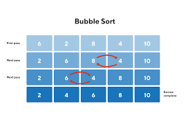

## **Ascending(Urut Naik)**

**Definisi:**

> Ascending adalah proses mengurutkan data dari **nilai terkecil ke terbesar.**

**Ciri-ciri:**

- Angka: dari kecil → besar
- Huruf: dari A → Z
- Waktu: dari paling awal → paling akhir

**Contoh:**

```
Data awal   : 8, 3, 10, 1, 6
Ascending   : 1, 3, 6, 8, 10
```

**Contoh String:**

```
Data awal   : "jeruk", "apel", "mangga"
Ascending   : "apel", "jeruk", "mangga"
```

## **Descending(Urutan Turun)**

**Definisi**

> Descending adalah proses mengurutkan data dari **nilai terbesar ke terkecil.**

**Ciri-ciri:**

- Angka: besar → kecil
- Huruf: Z → A
- Waktu: terbaru → terlama

**Contoh:**

```
Data awal   : 8, 3, 10, 1, 6
Descending  : 10, 8, 6, 3, 1
```

### **Contoh:**

```python
def bubbleSort(listData):
    print('Data yang akan diurutkan : ', listData)
    count = 0
    for outIter in range(len(listData)-1, -1, -1):
        print('outIter =', outIter)
        count += 1
        print('Iterasi ke-', count, ':')
        for i in range(outIter):
            if listData[i] > listData[i+1]:

                temp = listData[i]
                listData[i] = listData[i+1]
                listData[i+1] = temp
                print(outIter, '=', listData)
        print('Data urut sementara:', listData)
    print('Hasil akhir:', listData)

a = [12, 0, 5, 1, 11, 20, 4, 2]
bubbleSort(a)

print('--')

b = [12, 11, 5, 1, 0]
bubbleSort(b)
```

```
Data yang akan diurutkan :  [12, 0, 5, 1, 11, 20, 4, 2]
outIter = 7
Iterasi ke- 1 :
7 = [0, 12, 5, 1, 11, 20, 4, 2]
7 = [0, 5, 12, 1, 11, 20, 4, 2]
7 = [0, 5, 1, 12, 11, 20, 4, 2]
7 = [0, 5, 1, 11, 12, 20, 4, 2]
7 = [0, 5, 1, 11, 12, 4, 20, 2]
7 = [0, 5, 1, 11, 12, 4, 2, 20]
Data urut sementara: [0, 5, 1, 11, 12, 4, 2, 20]
outIter = 6
Iterasi ke- 2 :
6 = [0, 1, 5, 11, 12, 4, 2, 20]
6 = [0, 1, 5, 11, 4, 12, 2, 20]
6 = [0, 1, 5, 11, 4, 2, 12, 20]
Data urut sementara: [0, 1, 5, 11, 4, 2, 12, 20]
outIter = 5
Iterasi ke- 3 :
5 = [0, 1, 5, 4, 11, 2, 12, 20]
5 = [0, 1, 5, 4, 2, 11, 12, 20]
Data urut sementara: [0, 1, 5, 4, 2, 11, 12, 20]
outIter = 4
Iterasi ke- 4 :
4 = [0, 1, 4, 5, 2, 11, 12, 20]
4 = [0, 1, 4, 2, 5, 11, 12, 20]
Data urut sementara: [0, 1, 4, 2, 5, 11, 12, 20]
outIter = 3
Iterasi ke- 5 :
3 = [0, 1, 2, 4, 5, 11, 12, 20]
Data urut sementara: [0, 1, 2, 4, 5, 11, 12, 20]
outIter = 2
Iterasi ke- 6 :
Data urut sementara: [0, 1, 2, 4, 5, 11, 12, 20]
outIter = 1
Iterasi ke- 7 :
Data urut sementara: [0, 1, 2, 4, 5, 11, 12, 20]
outIter = 0
Iterasi ke- 8 :
Data urut sementara: [0, 1, 2, 4, 5, 11, 12, 20]
Hasil akhir: [0, 1, 2, 4, 5, 11, 12, 20]
```

[output cut: 13 more lines]

```
3 = [5, 1, 0, 11, 12]
Data urut sementara: [5, 1, 0, 11, 12]
outIter = 2
Iterasi ke- 3 :
2 = [1, 5, 0, 11, 12]
2 = [1, 0, 5, 11, 12]
Data urut sementara: [1, 0, 5, 11, 12]
outIter = 1
Iterasi ke- 4 :
1 = [0, 1, 5, 11, 12]
Data urut sementara: [0, 1, 5, 11, 12]
outIter = 0
Iterasi ke- 5 :
Data urut sementara: [0, 1, 5, 11, 12]
Hasil akhir: [0, 1, 5, 11, 12]
```

```python
def bubbleSort(listData):
    print('Data yang akan diurutkan : ', listData)
    count = 0
    for outIter in range(len(listData)):
        print('outIter =', outIter)
        count += 1
        print('Iterasi ke-', count, ':')
        for i in range(len(listData)-1-outIter):
            if listData[i] > listData[i+1]:
                temp = listData[i]
                listData[i] = listData[i+1]
                listData[i+1] = temp
                print(outIter, '=', listData)
        print('Data urut sementara:', listData)
    print('Hasil akhir:', listData)


a = [12, 0, 5, 1, 11, 20, 4, 2]
bubbleSort(a)

print('--')

b = [12, 11, 5, 1, 0]
bubbleSort(b)
```

```
Data yang akan diurutkan :  [12, 0, 5, 1, 11, 20, 4, 2]
outIter = 0
Iterasi ke- 1 :
0 = [0, 12, 5, 1, 11, 20, 4, 2]
0 = [0, 5, 12, 1, 11, 20, 4, 2]
0 = [0, 5, 1, 12, 11, 20, 4, 2]
0 = [0, 5, 1, 11, 12, 20, 4, 2]
0 = [0, 5, 1, 11, 12, 4, 20, 2]
0 = [0, 5, 1, 11, 12, 4, 2, 20]
Data urut sementara: [0, 5, 1, 11, 12, 4, 2, 20]
outIter = 1
Iterasi ke- 2 :
1 = [0, 1, 5, 11, 12, 4, 2, 20]
1 = [0, 1, 5, 11, 4, 12, 2, 20]
1 = [0, 1, 5, 11, 4, 2, 12, 20]
Data urut sementara: [0, 1, 5, 11, 4, 2, 12, 20]
outIter = 2
Iterasi ke- 3 :
2 = [0, 1, 5, 4, 11, 2, 12, 20]
2 = [0, 1, 5, 4, 2, 11, 12, 20]
Data urut sementara: [0, 1, 5, 4, 2, 11, 12, 20]
outIter = 3
Iterasi ke- 4 :
3 = [0, 1, 4, 5, 2, 11, 12, 20]
3 = [0, 1, 4, 2, 5, 11, 12, 20]
Data urut sementara: [0, 1, 4, 2, 5, 11, 12, 20]
outIter = 4
Iterasi ke- 5 :
4 = [0, 1, 2, 4, 5, 11, 12, 20]
Data urut sementara: [0, 1, 2, 4, 5, 11, 12, 20]
outIter = 5
Iterasi ke- 6 :
Data urut sementara: [0, 1, 2, 4, 5, 11, 12, 20]
outIter = 6
Iterasi ke- 7 :
Data urut sementara: [0, 1, 2, 4, 5, 11, 12, 20]
outIter = 7
Iterasi ke- 8 :
Data urut sementara: [0, 1, 2, 4, 5, 11, 12, 20]
Hasil akhir: [0, 1, 2, 4, 5, 11, 12, 20]
```

[output cut: 13 more lines]

```
1 = [5, 1, 0, 11, 12]
Data urut sementara: [5, 1, 0, 11, 12]
outIter = 2
Iterasi ke- 3 :
2 = [1, 5, 0, 11, 12]
2 = [1, 0, 5, 11, 12]
Data urut sementara: [1, 0, 5, 11, 12]
outIter = 3
Iterasi ke- 4 :
3 = [0, 1, 5, 11, 12]
Data urut sementara: [0, 1, 5, 11, 12]
outIter = 4
Iterasi ke- 5 :
Data urut sementara: [0, 1, 5, 11, 12]
Hasil akhir: [0, 1, 5, 11, 12]
```

```python
lst = [5,0,1,10,7,2,5,4,6,9]
print(lst)
for k in range(1,len(lst)):
    for i in range(0,len(lst)-1):
        if lst[i]>lst[i+1]:
            lst[i],lst[i+1] = lst[i+1],lst[i]
            print(lst)
print("")

for k in range(1,len(lst)):
    for i in range(0,len(lst)-1):
        if lst[i]<lst[i+1]:
            lst[i],lst[i+1] = lst[i+1],lst[i]
            print(lst)
```

```
[5, 0, 1, 10, 7, 2, 5, 4, 6, 9]
[0, 5, 1, 10, 7, 2, 5, 4, 6, 9]
[0, 1, 5, 10, 7, 2, 5, 4, 6, 9]
[0, 1, 5, 7, 10, 2, 5, 4, 6, 9]
[0, 1, 5, 7, 2, 10, 5, 4, 6, 9]
[0, 1, 5, 7, 2, 5, 10, 4, 6, 9]
[0, 1, 5, 7, 2, 5, 4, 10, 6, 9]
[0, 1, 5, 7, 2, 5, 4, 6, 10, 9]
[0, 1, 5, 7, 2, 5, 4, 6, 9, 10]
[0, 1, 5, 2, 7, 5, 4, 6, 9, 10]
[0, 1, 5, 2, 5, 7, 4, 6, 9, 10]
[0, 1, 5, 2, 5, 4, 7, 6, 9, 10]
[0, 1, 5, 2, 5, 4, 6, 7, 9, 10]
[0, 1, 2, 5, 5, 4, 6, 7, 9, 10]
[0, 1, 2, 5, 4, 5, 6, 7, 9, 10]
```

[output cut: 46 more lines]

```python
def bubbleSort(lst, ascending=True):
    print("Data awal:", lst)
    for k in range(1, len(lst)):
        for i in range(0, len(lst)-1):
            if ascending:
                if lst[i] > lst[i+1]:
                    lst[i], lst[i+1] = lst[i+1], lst[i]
                    print(lst)
            else:
                if lst[i] < lst[i+1]:
                    lst[i], lst[i+1] = lst[i+1], lst[i]
                    print(lst)
    print("Hasil akhir:", lst)


data1 = [5,0,1,10,7,2,5,4,6,9]

print("Ascending:")
bubbleSort(data1.copy(), ascending=True)

print("\nDescending:")
bubbleSort(data1.copy(), ascending=False)
```

```
Ascending:
Data awal: [5, 0, 1, 10, 7, 2, 5, 4, 6, 9]
[0, 5, 1, 10, 7, 2, 5, 4, 6, 9]
[0, 1, 5, 10, 7, 2, 5, 4, 6, 9]
[0, 1, 5, 7, 10, 2, 5, 4, 6, 9]
[0, 1, 5, 7, 2, 10, 5, 4, 6, 9]
[0, 1, 5, 7, 2, 5, 10, 4, 6, 9]
[0, 1, 5, 7, 2, 5, 4, 10, 6, 9]
[0, 1, 5, 7, 2, 5, 4, 6, 10, 9]
[0, 1, 5, 7, 2, 5, 4, 6, 9, 10]
[0, 1, 5, 2, 7, 5, 4, 6, 9, 10]
[0, 1, 5, 2, 5, 7, 4, 6, 9, 10]
[0, 1, 5, 2, 5, 4, 7, 6, 9, 10]
[0, 1, 5, 2, 5, 4, 6, 7, 9, 10]
[0, 1, 2, 5, 5, 4, 6, 7, 9, 10]
```

[output cut: 36 more lines]

```python
lst = [4,7,1,9,3,10,6]
print(lst)
for i in range(0,len(lst)-1):
    min=i
    for j in range(i+1,len(lst)):
        if lst[j]<lst[min]:
            min = j
        lst[i],lst[min]=lst[min],lst[i]
        print(lst)
```

```
[4, 7, 1, 9, 3, 10, 6]
[4, 7, 1, 9, 3, 10, 6]
[1, 7, 4, 9, 3, 10, 6]
[4, 7, 1, 9, 3, 10, 6]
[1, 7, 4, 9, 3, 10, 6]
[4, 7, 1, 9, 3, 10, 6]
[1, 7, 4, 9, 3, 10, 6]
[1, 4, 7, 9, 3, 10, 6]
[1, 7, 4, 9, 3, 10, 6]
[1, 3, 4, 9, 7, 10, 6]
[1, 7, 4, 9, 3, 10, 6]
[1, 3, 4, 9, 7, 10, 6]
[1, 3, 4, 9, 7, 10, 6]
[1, 3, 4, 9, 7, 10, 6]
[1, 3, 4, 9, 7, 10, 6]
[1, 3, 4, 9, 7, 10, 6]
[1, 3, 4, 7, 9, 10, 6]
[1, 3, 4, 9, 7, 10, 6]
[1, 3, 4, 6, 7, 10, 9]
[1, 3, 4, 6, 7, 10, 9]
[1, 3, 4, 6, 7, 10, 9]
[1, 3, 4, 6, 7, 9, 10]
```